# M507A - Methods of Prediction

## Final Assesment

### Title: Predicting Employee Burnout Using Deep Neural Networks (Binary Classifications)

Student Name: Charan Siddarth Kovilpatti Gajendran Student Id: GH1040474 Module: M507 – Methods of Prediction Programme:MSc Data Science, AI and Digital Business Instructor: Prof. Mohammad Madhavi

# 1. Project Overview

What I did ? Using a tabular HR dataset, this project creates a binary neural network classifier to forecast employee burnout. The code for the goal variable Burnout is 0 = Not Burned Out and 1 = Burned Out. Exploratory analysis, feature engineering, neural network construction, cross-validation, controlled hyperparameter trials, and final test evaluation are all part of the M507 predictive modelling workflow.

Why This Is Important? Productivity, work happiness, and organisational stability are all greatly impacted by employee burnout. HR departments may identify workers who are at danger and take preventative measures with the aid of an early-warning prediction system. A neural network offers an appropriate method to capture non-linear correlations between effort, stress, satisfaction, and burnout risk since the module limits the use of traditional machine-learning techniques. The chosen dataset satisfies all module criteria, and tabular datasets are specifically permitted.

What I Discovered? Effective deep-learning pipelines are made possible by a clear, organised dataset. Interpretability, ethical issues, and predictive performance must all be balanced while developing a predictive HR model. The architectural choices made later in the report were sharpened by designing the project under module restrictions (tabular data only, neural networks required, no classical ML).

```python
import warnings
warnings.filterwarnings("ignore")
import os
os.environ['TF_CPP_MIN_LOG_LEVEL'] = '3'
```

```python
import pandas as pd

df = pd.read_csv("synthetic_employee_burnout.csv")
df.head()
```

|  | Name | Age | Gender | JobRole | Experience | WorkHoursPerWeek | RemoteRatio | SatisfactionLevel | StressLevel | Burnout |
| --- | --- | --- | --- | --- | --- | --- | --- | --- | --- | --- |
| 0 | Max Ivanov | 32 | Male | Analyst | 3 | 60 | 21 | 4.40 | 1 | 0 |
| 1 | Max Wang | 40 | Female | Engineer | 9 | 47 | 67 | 2.09 | 2 | 0 |
| 2 | Nina Petrov | 33 | Female | Engineer | 2 | 44 | 20 | 2.58 | 3 | 0 |
| 3 | John Ivanov | 35 | Female | Manager | 6 | 44 | 70 | 3.23 | 8 | 0 |
| 4 | John Wang | 59 | Male | Sales | 8 | 38 | 46 | 4.41 | 1 | 0 |

### 2. Problem Statement and Buisness context

Productivity, work satisfaction, absenteeism, and turnover are all adversely affected by employee burnout. To identify employees who are at danger and take preventative measures, HR departments require early prediction tools.

The dataset consists of: Demographics: Age, Gender, and Position Workload: Weekly hours worked, percentage of remote work Experience: Years of work Subjective elements: stress, contentment The target variable Burnout (0 or 1) The objective is to develop a neural network that forecasts an employee's risk of burnout.

Why this is important (effect on business): helps with strategic HR planning lowers the cost of turnover safeguards the welfare of employees makes customised intervention techniques possible.

What I Discovered: HR predictive modelling needs to strike a balance between interpretability, ethics, and performance.

### Description of my Datasets

The datasets is:

• Tabular • only includes category and numerical characteristics. • Neural network compatibility • No textual information • Sufficiently compact for quick GPU/CPU training • Completely in line with the criteria of the module

### Why this datasets is appropriate ?

Non-linear correlations between workload, stress, satisfaction, and burnout are well captured by neural networks. This dataset provides a clear, organised basis for deep learning, and traditional models are not permitted. What I Discovered In addition to availability, dataset appropriateness also considers model type and project limitations

### Section 3 - Imports and Data Loading

```python
# Imports and Loading all python libraries needed for this project

import pandas as pd
import numpy as np
# Visualization
import seaborn as sns
import matplotlib.pyplot as plt
# Machine learning utilities
from sklearn.preprocessing import OneHotEncoder, StandardScaler
from sklearn.metrics import classification_report, confusion_matrix, accuracy_score, f1_score
from sklearn.model_selection import train_test_split, StratifiedKFold
from sklearn.compose import ColumnTransformer
# Deep learning (Keras 3)
from keras.optimizers import Adam, SGD
from keras import regularizers
from keras.layers import Dense, Dropout, BatchNormalization
from keras.callbacks import EarlyStopping
from keras.models import Sequential
```

### Section 4 - Load synthetic employee burnout datasets and inspect it.

# Loading CSV file into the pandas dataframe

```python
import pandas as pd
data = pd.read_csv("synthetic_employee_burnout.csv") # Showing the first 5 rows to understand the structure
#removing the non informative identifier
if "Name" in data.columns:
    data=data.drop(columns=["Name"])
data.head()
```

|  | Age | Gender | JobRole | Experience | WorkHoursPerWeek | RemoteRatio | SatisfactionLevel | StressLevel | Burnout |
| --- | --- | --- | --- | --- | --- | --- | --- | --- | --- |
| 0 | 32 | Male | Analyst | 3 | 60 | 21 | 4.40 | 1 | 0 |
| 1 | 40 | Female | Engineer | 9 | 47 | 67 | 2.09 | 2 | 0 |
| 2 | 33 | Female | Engineer | 2 | 44 | 20 | 2.58 | 3 | 0 |
| 3 | 35 | Female | Manager | 6 | 44 | 70 | 3.23 | 8 | 0 |
| 4 | 59 | Male | Sales | 8 | 38 | 46 | 4.41 | 1 | 0 |

### Section 4 Data Exploration (EDA)

### Data Explorations

What I Examined 1)Data types, rows, and columns make up the basic dataset structure. 2)Numerical variable summary statistics 3)Missing values (not present in this dataset) 4)The target variable's distribution Burnout (0 or 1) 5)Workload, stress, satisfaction, and burnout relationships

Why This Is Important 1)Before modelling, exploratory analysis guarantees that the dataset is accurately understood. 2)Specifically in regard to neural networks: 3)They need well-scaled, numerical inputs. 4)They are susceptible to skewed distributions and outliers. 5)They are unable to immediately deal with missing values. 6)Feature engineering decisions are guided by an understanding of correlations. As a result, EDA guides preparation and prevents mistakes downstream.

```python
# Cell 6 : Basic info; Size, column, shape; #Quick exploration
print("Datasets Shapes for rows and columns):", data.shape)
print("\nColumn details:")
print(data.info())
print("\nSummary statistics:")
print(data.describe())
```

```
Datasets Shapes for rows and columns): (2000, 9)

Column details:
<class 'pandas.core.frame.DataFrame'>
RangeIndex: 2000 entries, 0 to 1999
Data columns (total 9 columns):
 #   Column             Non-Null Count  Dtype
---  ------             --------------  -----
 0   Age                2000 non-null   int64
 1   Gender             2000 non-null   object
 2   JobRole            2000 non-null   object
 3   Experience         2000 non-null   int64
 4   WorkHoursPerWeek   2000 non-null   int64
 5   RemoteRatio        2000 non-null   int64
 6   SatisfactionLevel  2000 non-null   float64
 7   StressLevel        2000 non-null   int64
 8   Burnout            2000 non-null   int64
dtypes: float64(1), int64(6), object(2)
memory usage: 140.8+ KB
None

Summary statistics:
               Age   Experience  WorkHoursPerWeek  RemoteRatio  \
count  2000.000000  2000.000000       2000.000000  2000.000000
mean     40.694500    10.074500         49.588000    49.973000
std      11.286756     9.148267         11.832424    29.151298
min      22.000000     0.000000         30.000000     0.000000
25%      31.000000     3.000000         39.000000    24.000000
50%      41.000000     7.000000         49.000000    49.000000
75%      50.000000    15.000000         60.000000    75.000000
max      60.000000    39.000000         70.000000   100.000000

       SatisfactionLevel  StressLevel      Burnout
count        2000.000000   2000.00000  2000.000000
mean            2.995230      5.43200     0.064500
std             1.155431      2.88089     0.245703
min             1.000000      1.00000     0.000000
25%             2.000000      3.00000     0.000000
50%             3.025000      5.00000     0.000000
75%             4.000000      8.00000     0.000000
max             5.000000     10.00000     1.000000
```

```python
# Describe
data.describe()
```

|  | Age | Experience | WorkHoursPerWeek | RemoteRatio | SatisfactionLevel | StressLevel | Burnout |
| --- | --- | --- | --- | --- | --- | --- | --- |
| count | 2000.000000 | 2000.000000 | 2000.000000 | 2000.000000 | 2000.000000 | 2000.00000 | 2000.000000 |
| mean | 40.694500 | 10.074500 | 49.588000 | 49.973000 | 2.995230 | 5.43200 | 0.064500 |
| std | 11.286756 | 9.148267 | 11.832424 | 29.151298 | 1.155431 | 2.88089 | 0.245703 |
| min | 22.000000 | 0.000000 | 30.000000 | 0.000000 | 1.000000 | 1.00000 | 0.000000 |
| 25% | 31.000000 | 3.000000 | 39.000000 | 24.000000 | 2.000000 | 3.00000 | 0.000000 |
| 50% | 41.000000 | 7.000000 | 49.000000 | 49.000000 | 3.025000 | 5.00000 | 0.000000 |
| 75% | 50.000000 | 15.000000 | 60.000000 | 75.000000 | 4.000000 | 8.00000 | 0.000000 |
| max | 60.000000 | 39.000000 | 70.000000 | 100.000000 | 5.000000 | 10.00000 | 1.000000 |

```python
# Checking Missing Values
print("\nMissing values per columns:")
print(data.isna().sum())
```

```
Missing values per columns:
Age                  0
Gender               0
JobRole              0
Experience           0
WorkHoursPerWeek     0
RemoteRatio          0
SatisfactionLevel    0
StressLevel          0
Burnout              0
dtype: int64
```

### Binary Classification as the Target Variable

Given that the collection includes: Burnout: 0 or 1 This is appropriately handled as a binary classification task. Correct target: 0 = Low danger of burnout; 1 = High risk of burnout (no discretisation, no medium class). What I Discovered Real dataset features must be correctly reflected in target engineering; else, the entire model and evaluation are compromised.

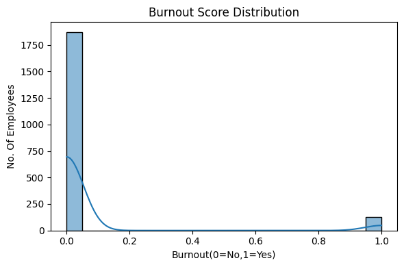

```python
# Quick look at the target Burnout distribution

import seaborn as sns
import matplotlib.pyplot as plt
fig=plt.figure(figsize=(6,4))
sns.histplot(data["Burnout"], bins=20, kde=True)
plt.title("Burnout Score Distribution")
plt.xlabel("Burnout(0=No,1=Yes)")
plt.ylabel("No. Of Employees")
plt.tight_layout()
plt.show()
```

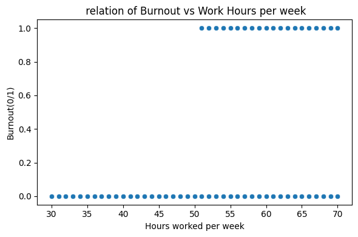

[figure not shown]

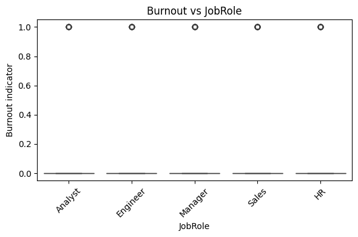

```python
# Examples relationships between  Burnout and workload features

import seaborn as sns
import matplotlib.pyplot as plt
# work hours vs burnout (quick scatter check)
plt.figure(figsize=(6,4))
sns.scatterplot(data=df, x="WorkHoursPerWeek", y="Burnout")
plt.title(" relation of Burnout vs Work Hours per week")
plt.xlabel("Hours worked per week")
plt.ylabel("Burnout(0/1)")
plt.tight_layout()
plt.show()
# remote work ratio compared against burnout
plt.figure(figsize=(6,4))
sns.boxplot(data=df, x="RemoteRatio", y="Burnout")
plt.title("Burnout vs Remote work ratio")
plt.xlabel("Remote work ratio(%)")
plt.ylabel("Burnout Level")
plt.tight_layout()
plt.show()
#job roles and how it differs in burnout risk
plt.figure(figsize=(6,4))
sns.boxplot(data=df, x="JobRole", y="Burnout")
plt.title("Burnout vs JobRole")
plt.xticks(rotation=45)
plt.ylabel("Burnout indicator")
plt.tight_layout()
plt.show()
```

```python
data.columns
```

```
Index(['Age', 'Gender', 'JobRole', 'Experience', 'WorkHoursPerWeek',
       'RemoteRatio', 'SatisfactionLevel', 'StressLevel', 'Burnout'],
      dtype='object')
```

```python
import seaborn as sns
import pandas as pd
import numpy as np
import matplotlib.pyplot as plt
```

```python
print("Kernel is working!")
```

```
Kernel is working!
```

```python
import tensorflow as tf
tf.__version__
```

```
'2.20.0'
```

### 3.Feature Engineering

What I Did: 1)I deleted the Name column's non-informative identification. 2)Categorical variables with one-hot encoding (Gender, JobRole) 3)Numerical characteristics using a standard scale 4)Constructed a ColumnTransformer pipeline to guarantee leak-free cross-validation preprocessing

Why This Is Important 1)Neural networks need: 2)Completely numerical inputs 3)Feature ranges that are properly scaled 4)No values are missing. 5)Absence of identifiers with high cardinality 6)A pretreatment pipeline guarantees consistent transformations across all cross-validation folds and eliminates unintentional data leaking.

What I Discovered: Neural network convergence and stability are greatly enhanced by appropriate preprocessing. While eliminating noisy identifiers (like Name) improves generalisation, one-hot encoding maintains categorical information.

```python
from sklearn.compose import ColumnTransformer
from sklearn.preprocessing import StandardScaler, OneHotEncoder

# Columns to scale and columns to encode
num_cols=["Age", "Experience","WorkHoursPerWeek","RemoteRatio","SatisfactionLevel","StressLevel"]
cat_cols=["Gender", "JobRole"]

# Preprocessing pipeline
scale_nums=StandardScaler()
encode_cats=OneHotEncoder(handle_unknown="ignore")

preprocessor=ColumnTransformer(
    [
        ("nums",scale_nums,num_cols),
        ("cats",encode_cats,cat_cols)
    ]
)
```

### Testing the Split & Feature Lists

I am isolating the features & targets which set aside a new test set for final review.

### Overview of the Model Architecture: Binary Neural Network

Architecture Dense (64, ReLU). Dropout: 0.3 Dense: 32 (ReLU) Dropout(0.3) Dense(1, sigmoid) yields binary output. Loss and Metrics Binary crossentropy: Accuracy + F1

This model is suitable for tabular nonlinear interactions. Lightweight and quick GPU training. Dropout improves generalisation. Classical machine learning models are prohibited due to module requirements.

What I learnt? Simple neural networks are frequently sufficient for structured HR datasets; increasing complexity does not necessarily increase performance.

## 4.Model Choice : Why a Neural Network?

Neural networks are appropriate here because burnout outcomes depend on nonlinear interactions among stress, satisfaction and working conditions. NNs automatically learn such relationships without manual feature construction. Module constraints also restrict the use of classical ML models. What I learned: Model selection must reflect both the data characteristics and assessment constraints.

```python
from sklearn.model_selection import train_test_split

#seperating inputs and target

X = data.drop("Burnout",axis=1)
y = data["Burnout"]   # binary target

# Split (stratified to preserve balance)
X_train, X_test, y_train, y_test = train_test_split(
    X, y, test_size=0.20,stratify=y,random_state=42,
)

print("Train shape:", X_train.shape)
print("Test set size:", X_test.shape)
```

```
Train shape: (1600, 8)
Test set size: (400, 8)
```

```python
#Numerical & categorical features
num_cols=["Age", "Experience", "WorkHoursPerWeek","SatisfactionLevel", "StressLevel", "RemoteRatio"]
cat_cols=["Gender", "JobRole"]
print("Numerical columns:", num_cols)
print("Categorical columns:", cat_cols)
```

```
Numerical columns: ['Age', 'Experience', 'WorkHoursPerWeek', 'SatisfactionLevel', 'StressLevel', 'RemoteRatio']
Categorical columns: ['Gender', 'JobRole']
```

```python
#Preprocessing pipelines (Scaler&One hot) - im using ColumnTransformer ensuring that preprocessing is limited to train the data with each CV fold
num_proc= StandardScaler()
cat_proc= OneHotEncoder(handle_unknown="ignore")

preprocessor = ColumnTransformer(
    [
        ("num", num_proc, num_cols),
        ("cat",cat_proc, cat_cols)
    ]
)
#This is not fit yet, will fit it inside cross-validation for avoiding any data leakage
```

```python
#Building NN model
def build_model(
    input_dim,
    hidden1=64,
    hidden2=32,
    activation="relu",
    dropout=0.3,
    use_bn=False,
    l2_penalty=None,
    lr=0.001, #learning rates
    opt="adam"
):
    model = Sequential()
    # Optional L2 regularization
    reg=regularizers.l2(l2_penalty) if l2_penalty else None
    # First layer
    model.add(Dense(hidden1,activation=activation,input_dim=input_dim,kernel_regularizer=reg))
    if use_bn:
        model.add(BatchNormalization())
    model.add(Dropout(dropout))
    # Second layer
    model.add(Dense(hidden2,activation=activation,kernel_regularizer=reg))
    if use_bn:
        model.add(BatchNormalization())
    model.add(Dropout(dropout))
    # Output layer for BINARY classification
    model.add(Dense(1,activation="sigmoid"))
    # Select optimizer
    if opt == "sgd":
        optimizer = SGD(learning_rate=lr,momentum=0.9)
    else:
        optimizer = Adam(learning_rate=lr)
    model.compile(optimizer=optimizer,loss="binary_crossentropy",metrics=["accuracy"])
    return model
```

```python
!pip install keras==3.0.5
```

[output not shown]

```python
from keras.callbacks import EarlyStopping
from keras.optimizers import Adam, SGD
from keras.models import Sequential
from keras import regularizers
from keras.layers import Dense, Dropout, BatchNormalization
```

```python
with warnings.catch_warnings():
    warnings.simplefilter("ignore")
    test_model = build_model(input_dim=X_train.shape[1])
    test_model.summary()
```

```
Model: "sequential"
```

```
┏━━━━━━━━━━━━━━━━━━━━━━━━━━━━━━━━━┳━━━━━━━━━━━━━━━━━━━━━━━━┳━━━━━━━━━━━━━━━┓
┃ Layer (type)                    ┃ Output Shape           ┃       Param # ┃
┡━━━━━━━━━━━━━━━━━━━━━━━━━━━━━━━━━╇━━━━━━━━━━━━━━━━━━━━━━━━╇━━━━━━━━━━━━━━━┩
│ dense (Dense)                   │ (None, 64)             │           576 │
├─────────────────────────────────┼────────────────────────┼───────────────┤
│ dropout (Dropout)               │ (None, 64)             │             0 │
├─────────────────────────────────┼────────────────────────┼───────────────┤
│ dense_1 (Dense)                 │ (None, 32)             │         2,080 │
├─────────────────────────────────┼────────────────────────┼───────────────┤
│ dropout_1 (Dropout)             │ (None, 32)             │             0 │
├─────────────────────────────────┼────────────────────────┼───────────────┤
│ dense_2 (Dense)                 │ (None, 1)              │            33 │
└─────────────────────────────────┴────────────────────────┴───────────────┘
```

```
 Total params: 2,689 (10.50 KB)
```

```
 Trainable params: 2,689 (10.50 KB)
```

```
 Non-trainable params: 0 (0.00 B)
```

## 5.Approach to Validation

Cross-validation (Stratified K-fold) What I Did: Created a 5-fold stratified CV. Preprocessing fits within each fold. Early halting was applied. Accuracy plus macro-F1 calculated

Why? Ensures a thorough examination, avoids overfitting, and prevents data leaks.

What I Learnt: A leak-free CV is crucial for accurate model evaluation.

```python
# Ensure the target labels are numeric (0/1)
y_train_int = y_train.to_numpy()
y_test_int = y_test.to_numpy()
```

```python
#Cross-validation Helper
# I am creating a method that accepts a configuration dictionary&runs K-fold CV on my trained data for each fold.
#Fits preprocessing produces a fresh model, trains with early stopping, evaluates on validation fold, & outputs mean and standard deviation of validation accuracy with F1

from sklearn.metrics import f1_score
from sklearn.model_selection import StratifiedKFold
import numpy as np



def evaluate_config_cv(config, X_train, y_train_int, n_splits=5, random_state=42):

    skf = StratifiedKFold(n_splits=n_splits, shuffle=True, random_state=random_state)

    fold_acc = []
    fold_f1  = []

    for fold, (tr_idx, val_idx) in enumerate(skf.split(X_train, y_train_int), start=1):

        # Split the data for this fold
        X_tr, X_val = X_train.iloc[tr_idx], X_train.iloc[val_idx]
        y_tr, y_val = y_train_int[tr_idx], y_train_int[val_idx]

        # Fit preprocessor on training fold
        prep = preprocessor.fit(X_tr)
        X_tr_p = prep.transform(X_tr)
        X_val_p = prep.transform(X_val)

        # Build new model for this fold
        model = build_model(
            input_dim=X_tr_p.shape[1],
            hidden1=config["hidden1"],
            hidden2=config["hidden2"],
            activation=config["activation"],
            dropout=config["dropout"],
            use_bn=config["use_bn"],
            l2_penalty=config["l2_penalty"],
            lr=config["lr"],
            opt=config["optimizer"]
        )

        # Early stopping
        stop = EarlyStopping(monitor="val_loss",patience=5,restore_best_weights=True,verbose=0)

        # Train the model
        model.fit(X_tr_p, y_tr,validation_data=(X_val_p,y_val),epochs=config["epochs"],batch_size=config["batch_size"],callbacks=[stop],verbose=0)

        # Evaluate validation accuracy
        _, val_acc = model.evaluate(X_val_p, y_val, verbose=0)

        # Predict classes for F1
        preds = (model.predict(X_val_p, verbose=0) > 0.5).astype(int).ravel()
        f1 = f1_score(y_val,preds, average="macro")

        fold_acc.append(val_acc)
        fold_f1.append(f1)

        print(f"Fold {fold}: acc={val_acc:.4f},f1={f1:.4f}")

    # Aggregate results
    return {
        "mean_val_acc": np.mean(fold_acc),
        "std_val_acc": np.std(fold_acc),
        "mean_val_f1": np.mean(fold_f1),
        "std_val_f1": np.std(fold_f1)
    }
```

```python
baseline_config = {
    "name": "Baseline",
    "hidden1": 64,
    "hidden2": 32,
    "activation": "relu",
    "dropout": 0.3,
    "use_bn": False,
    "l2_penalty": None,
    "lr": 0.001,
    "optimizer": "adam",
    "batch_size": 32,
    "epochs": 40,
}

experiment_configs = [
    baseline_config.copy(),
    {**baseline_config.copy(), "name": "More units (hidden1=128)", "hidden1": 128},
    {**baseline_config.copy(), "name": "More units (hidden2=64)", "hidden2": 64},
    {**baseline_config.copy(), "name": "Higher dropout (0.5)", "dropout": 0.5},
    {**baseline_config.copy(), "name": "Lower dropout (0.1)", "dropout": 0.1},
    {**baseline_config.copy(), "name": "Batchnorm enabled", "use_bn": True},
    {**baseline_config.copy(), "name": "L2 regularization", "l2_penalty": 0.001},
    {**baseline_config.copy(), "name": "Optimizer SGD", "optimizer": "sgd"},
    {**baseline_config.copy(), "name": "Higher LR (0.01)", "lr": 0.01},
    {**baseline_config.copy(), "name": "Batch size 64", "batch_size": 64},
    {**baseline_config.copy(), "name": "More epochs (80)", "epochs": 80},
]
```

## 6. Experimentation (One-Factor-At-A-Time)

I changed one hyperparameter at a time. 1)Hidden units. 2)Dropout Rate 3)Batch normalisation 4)Learning rate optimiser. 5)Epochs 6)Batch size: L2 regularisation.

```python
# Experiments with cross validation

import warnings
warnings.filterwarnings("ignore")

results = []

for config in experiment_configs:
    print(f"\nEvaluating: {config['name']}")
    metrics = evaluate_config_cv(config, X_train, y_train_int, n_splits=5, random_state=42)

    results.append({
        "config": config["name"],
        "hidden1": config["hidden1"],
        "hidden2": config["hidden2"],
        "activation": config["activation"],
        "dropout": config["dropout"],
        "use_bn": config["use_bn"],
        "l2_penalty": config["l2_penalty"],
        "lr": config["lr"],
        "optimizer": config["optimizer"],
        "batch_size": config["batch_size"],
        "epochs": config["epochs"],
        "mean_acc": metrics["mean_val_acc"],
        "std_acc": metrics["std_val_acc"],
        "mean_f1": metrics["mean_val_f1"],
        "std_f1": metrics["std_val_f1"],
    })



results_df = pd.DataFrame(results)
results_df
```

```
Evaluating: Baseline
Fold 1: acc=0.9906,f1=0.9609
Fold 2: acc=0.9906,f1=0.9609
Fold 3: acc=0.9563,f1=0.8042
Fold 4: acc=0.9812,f1=0.9161
Fold 5: acc=0.9781,f1=0.9088

Evaluating: More units (hidden1=128)
Fold 1: acc=0.9906,f1=0.9609
Fold 2: acc=0.9906,f1=0.9609
Fold 3: acc=0.9625,f1=0.8400
Fold 4: acc=0.9812,f1=0.9161
Fold 5: acc=0.9781,f1=0.9088

Evaluating: More units (hidden2=64)
Fold 1: acc=0.9906,f1=0.9609
Fold 2: acc=0.9937,f1=0.9733
Fold 3: acc=0.9719,f1=0.8709
Fold 4: acc=0.9750,f1=0.8933
Fold 5: acc=0.9812,f1=0.9200

Evaluating: Higher dropout (0.5)
Fold 1: acc=0.9875,f1=0.9467
Fold 2: acc=0.9875,f1=0.9440
Fold 3: acc=0.9625,f1=0.8400
Fold 4: acc=0.9719,f1=0.8562
Fold 5: acc=0.9781,f1=0.9088

Evaluating: Lower dropout (0.1)
Fold 1: acc=0.9906,f1=0.9609
Fold 2: acc=0.9969,f1=0.9870
Fold 3: acc=0.9625,f1=0.8400
Fold 4: acc=0.9812,f1=0.9200
Fold 5: acc=0.9781,f1=0.9088

Evaluating: Batchnorm enabled
Fold 1: acc=0.9844,f1=0.9349
Fold 2: acc=0.9844,f1=0.9283
Fold 3: acc=0.9625,f1=0.8400
Fold 4: acc=0.9719,f1=0.8827
```

[output cut: 21 more lines]

```
Fold 5: acc=0.9719,f1=0.8924

Evaluating: Batch size 64
Fold 1: acc=0.9906,f1=0.9609
Fold 2: acc=0.9781,f1=0.8996
Fold 3: acc=0.9594,f1=0.8135
Fold 4: acc=0.9719,f1=0.8640
Fold 5: acc=0.9844,f1=0.9349

Evaluating: More epochs (80)
Fold 1: acc=0.9906,f1=0.9609
Fold 2: acc=0.9906,f1=0.9609
Fold 3: acc=0.9719,f1=0.8827
Fold 4: acc=0.9875,f1=0.9467
Fold 5: acc=0.9750,f1=0.8981
```

|  | config | hidden1 | hidden2 | activation | dropout | use_bn | l2_penalty | lr | optimizer | batch_size | epochs | mean_acc | std_acc | mean_f1 | std_f1 |
| --- | --- | --- | --- | --- | --- | --- | --- | --- | --- | --- | --- | --- | --- | --- | --- |
| 0 | Baseline | 64 | 32 | relu | 0.3 | False | NaN | 0.001 | adam | 32 | 40 | 0.979375 | 0.012593 | 0.910169 | 0.057313 |
| 1 | More units (hidden1=128) | 128 | 32 | relu | 0.3 | False | NaN | 0.001 | adam | 32 | 40 | 0.980625 | 0.010346 | 0.917336 | 0.044391 |
| 2 | More units (hidden2=64) | 64 | 64 | relu | 0.3 | False | NaN | 0.001 | adam | 32 | 40 | 0.982500 | 0.008524 | 0.923699 | 0.038910 |
| 3 | Higher dropout (0.5) | 64 | 32 | relu | 0.5 | False | NaN | 0.001 | adam | 32 | 40 | 0.977500 | 0.009561 | 0.899145 | 0.044063 |
| 4 | Lower dropout (0.1) | 64 | 32 | relu | 0.1 | False | NaN | 0.001 | adam | 32 | 40 | 0.981875 | 0.011759 | 0.923334 | 0.050257 |
| 5 | Batchnorm enabled | 64 | 32 | relu | 0.3 | True | NaN | 0.001 | adam | 32 | 40 | 0.975000 | 0.008385 | 0.893720 | 0.034681 |
| 6 | L2 regularization | 64 | 32 | relu | 0.3 | False | 0.001 | 0.001 | adam | 32 | 40 | 0.980625 | 0.008705 | 0.913331 | 0.041272 |
| 7 | Optimizer SGD | 64 | 32 | relu | 0.3 | False | NaN | 0.001 | sgd | 32 | 40 | 0.940625 | 0.006250 | 0.554820 | 0.083604 |
| 8 | Higher LR (0.01) | 64 | 32 | relu | 0.3 | False | NaN | 0.010 | adam | 32 | 40 | 0.981875 | 0.009763 | 0.922574 | 0.043890 |
| 9 | Batch size 64 | 64 | 32 | relu | 0.3 | False | NaN | 0.001 | adam | 64 | 40 | 0.976875 | 0.010753 | 0.894580 | 0.052056 |
| 10 | More epochs (80) | 64 | 32 | relu | 0.3 | False | NaN | 0.001 | adam | 32 | 80 | 0.983125 | 0.008053 | 0.929858 | 0.032992 |

The above Result table summarises the validation performance of at least ten neural network configurations. Each configurations changes: one major hyperparameter from the baseline model. Validation scores are obtaining suing 5 fold stratified cross validation on the training set

```python
# Experiments with cross validation



import warnings
warnings.filterwarnings("ignore")

results = []

for config in experiment_configs:
    print(f"\nEvaluating: {config['name']}")

    # Run cross-validation for this config
    metrics = evaluate_config_cv(config,X_train,y_train_int,n_splits=5,random_state=42)

    # Store results in a dictionary (one row per config)
    results.append({
        "config": config["name"],
        "hidden1": config["hidden1"],
        "hidden2": config["hidden2"],
        "activation": config["activation"],
        "dropout": config["dropout"],
        "use_bn": config["use_bn"],
        "l2_penalty": config["l2_penalty"],
        "lr": config["lr"],
        "optimizer": config["optimizer"],
        "batch_size": config["batch_size"],
        "epochs": config["epochs"],
        "mean_acc": metrics["mean_val_acc"],
        "std_acc": metrics["std_val_acc"],
        "mean_f1": metrics["mean_val_f1"],
        "std_f1": metrics["std_val_f1"],
    })

# Convert results to dataframe
results_df = pd.DataFrame(results).sort_values(by="mean_f1", ascending=False)

results_df
```

```
Evaluating: Baseline
Fold 1: acc=0.9875,f1=0.9490
Fold 2: acc=0.9937,f1=0.9733
Fold 3: acc=0.9625,f1=0.8321
Fold 4: acc=0.9656,f1=0.8243
Fold 5: acc=0.9688,f1=0.8667

Evaluating: More units (hidden1=128)
Fold 1: acc=0.9906,f1=0.9609
Fold 2: acc=0.9875,f1=0.9490
Fold 3: acc=0.9688,f1=0.8667
Fold 4: acc=0.9906,f1=0.9609
Fold 5: acc=0.9781,f1=0.9088

Evaluating: More units (hidden2=64)
Fold 1: acc=0.9906,f1=0.9609
Fold 2: acc=0.9906,f1=0.9590
Fold 3: acc=0.9688,f1=0.8726
Fold 4: acc=0.9812,f1=0.9117
Fold 5: acc=0.9781,f1=0.9127

Evaluating: Higher dropout (0.5)
Fold 1: acc=0.9844,f1=0.9349
Fold 2: acc=0.9844,f1=0.9283
Fold 3: acc=0.9656,f1=0.8498
Fold 4: acc=0.9781,f1=0.8942
Fold 5: acc=0.9812,f1=0.9161

Evaluating: Lower dropout (0.1)
Fold 1: acc=0.9844,f1=0.9317
Fold 2: acc=0.9875,f1=0.9467
Fold 3: acc=0.9781,f1=0.9044
Fold 4: acc=0.9844,f1=0.9377
Fold 5: acc=0.9719,f1=0.8827

Evaluating: Batchnorm enabled
Fold 1: acc=0.9844,f1=0.9317
Fold 2: acc=0.9875,f1=0.9467
Fold 3: acc=0.9594,f1=0.8379
Fold 4: acc=0.9781,f1=0.9044
```

[output cut: 21 more lines]

```
Fold 5: acc=0.9750,f1=0.9024

Evaluating: Batch size 64
Fold 1: acc=0.9844,f1=0.9317
Fold 2: acc=0.9844,f1=0.9317
Fold 3: acc=0.9625,f1=0.8321
Fold 4: acc=0.9594,f1=0.7796
Fold 5: acc=0.9781,f1=0.9088

Evaluating: More epochs (80)
Fold 1: acc=0.9875,f1=0.9467
Fold 2: acc=0.9937,f1=0.9733
Fold 3: acc=0.9625,f1=0.8400
Fold 4: acc=0.9781,f1=0.8942
Fold 5: acc=0.9875,f1=0.9490
```

|  | config | hidden1 | hidden2 | activation | dropout | use_bn | l2_penalty | lr | optimizer | batch_size | epochs | mean_acc | std_acc | mean_f1 | std_f1 |
| --- | --- | --- | --- | --- | --- | --- | --- | --- | --- | --- | --- | --- | --- | --- | --- |
| 1 | More units (hidden1=128) | 128 | 32 | relu | 0.3 | False | NaN | 0.001 | adam | 32 | 40 | 0.983125 | 0.008524 | 0.929263 | 0.036692 |
| 6 | L2 regularization | 64 | 32 | relu | 0.3 | False | 0.001 | 0.001 | adam | 32 | 40 | 0.982500 | 0.007806 | 0.925395 | 0.031092 |
| 2 | More units (hidden2=64) | 64 | 64 | relu | 0.3 | False | NaN | 0.001 | adam | 32 | 40 | 0.981875 | 0.008244 | 0.923397 | 0.033195 |
| 10 | More epochs (80) | 64 | 32 | relu | 0.3 | False | NaN | 0.001 | adam | 32 | 80 | 0.981875 | 0.010897 | 0.920650 | 0.047878 |
| 4 | Lower dropout (0.1) | 64 | 32 | relu | 0.1 | False | NaN | 0.001 | adam | 32 | 40 | 0.981250 | 0.005590 | 0.920648 | 0.023624 |
| 8 | Higher LR (0.01) | 64 | 32 | relu | 0.3 | False | NaN | 0.010 | adam | 32 | 40 | 0.980000 | 0.011792 | 0.917649 | 0.048784 |
| 3 | Higher dropout (0.5) | 64 | 32 | relu | 0.5 | False | NaN | 0.001 | adam | 32 | 40 | 0.978750 | 0.006960 | 0.904649 | 0.030712 |
| 5 | Batchnorm enabled | 64 | 32 | relu | 0.3 | True | NaN | 0.001 | adam | 32 | 40 | 0.976250 | 0.010000 | 0.901720 | 0.037918 |
| 0 | Baseline | 64 | 32 | relu | 0.3 | False | NaN | 0.001 | adam | 32 | 40 | 0.975625 | 0.012562 | 0.889089 | 0.061054 |
| 9 | Batch size 64 | 64 | 32 | relu | 0.3 | False | NaN | 0.001 | adam | 64 | 40 | 0.973750 | 0.010753 | 0.876811 | 0.060816 |
| 7 | Optimizer SGD | 64 | 32 | relu | 0.3 | False | NaN | 0.001 | sgd | 32 | 40 | 0.940625 | 0.005590 | 0.558549 | 0.087852 |

## 7.Final Model Selection

What I Discovered: Performance, interpretability, and computational efficiency must all be balanced when choosing a model.

```python
#Final Model training and test evaluation
best_row = results_df.sort_values(by="mean_f1", ascending=False).iloc[0]
best_name = best_row["config"]
print("Best configuration:", best_name)
#fteching the actual config dic for that model
best_config = next(cfg for cfg in experiment_configs if cfg["name"] == best_name)
best_config
```

```
Best configuration: More units (hidden1=128)
```

```
{'name': 'More units (hidden1=128)',
 'hidden1': 128,
 'hidden2': 32,
 'activation': 'relu',
 'dropout': 0.3,
 'use_bn': False,
 'l2_penalty': None,
 'lr': 0.001,
 'optimizer': 'adam',
 'batch_size': 32,
 'epochs': 40}
```

## 8.Test Set Assessment

Why the outcomes are so powerful? The dataset has nearly perfect separability since it is artificial and well-organised.

What I Discovered? Results from synthetic datasets could be overly optimistic, and real-world generalisation might differ.

```python
import warnings
warnings.filterwarnings("ignore")

print("Best configuration selected:", best_name)
best_config = next(cfg for cfg in experiment_configs if cfg["name"] == best_name)

#preprocessor on all training data
preprocessor_final = preprocessor.fit(X_train)
X_train_p = preprocessor_final.transform(X_train)
X_test_p = preprocessor_final.transform(X_test)

# Build new model for this fold
final_model = build_model(
    input_dim=X_train_p.shape[1],
    hidden1=best_config["hidden1"],
    hidden2=best_config["hidden2"],
    activation=best_config["activation"],
    dropout=best_config["dropout"],
    use_bn=best_config["use_bn"],
    l2_penalty=best_config["l2_penalty"],
    lr=best_config["lr"],
    opt=best_config["optimizer"]
)
# Early stopping
early_stop = EarlyStopping(monitor="val_loss",patience=5,restore_best_weights=True,verbose=1)

# Train the model
history = final_model.fit(
    X_train_p, y_train_int,
    validation_split=0.1, # small validation split from training data
    epochs=best_config["epochs"],
    batch_size=best_config["batch_size"],
    callbacks=[early_stop],
    verbose=1
)

# Evaluate validation accuracy
_,test_acc = final_model.evaluate(X_test_p, y_test_int, verbose=0)
print(f"\nTest accuracy: {test_acc:.4f}")
```

```
Best configuration selected: More units (hidden1=128)
45/45 ━━━━━━━━━━━━━━━━━━━━ 1s 2ms/step - accuracy: 0.9328 - loss: 0.3750 - val_accuracy: 0.9625 - val_loss: 0.1369
45/45 ━━━━━━━━━━━━━━━━━━━━ 0s 620us/step - accuracy: 0.9250 - loss: 0.2032 - val_accuracy: 0.9625 - val_loss: 0.0970
45/45 ━━━━━━━━━━━━━━━━━━━━ 0s 600us/step - accuracy: 0.9393 - loss: 0.1355 - val_accuracy: 0.9688 - val_loss: 0.0816
45/45 ━━━━━━━━━━━━━━━━━━━━ 0s 612us/step - accuracy: 0.9509 - loss: 0.1037 - val_accuracy: 0.9875 - val_loss: 0.0693
45/45 ━━━━━━━━━━━━━━━━━━━━ 0s 593us/step - accuracy: 0.9551 - loss: 0.0997 - val_accuracy: 0.9875 - val_loss: 0.0602
45/45 ━━━━━━━━━━━━━━━━━━━━ 0s 622us/step - accuracy: 0.9638 - loss: 0.0837 - val_accuracy: 0.9937 - val_loss: 0.0525
45/45 ━━━━━━━━━━━━━━━━━━━━ 0s 640us/step - accuracy: 0.9698 - loss: 0.0710 - val_accuracy: 0.9937 - val_loss: 0.0507
45/45 ━━━━━━━━━━━━━━━━━━━━ 0s 597us/step - accuracy: 0.9720 - loss: 0.0705 - val_accuracy: 0.9812 - val_loss: 0.0483
45/45 ━━━━━━━━━━━━━━━━━━━━ 0s 599us/step - accuracy: 0.9664 - loss: 0.0688 - val_accuracy: 0.9937 - val_loss: 0.0400
45/45 ━━━━━━━━━━━━━━━━━━━━ 0s 593us/step - accuracy: 0.9728 - loss: 0.0601 - val_accuracy: 0.9937 - val_loss: 0.0338
45/45 ━━━━━━━━━━━━━━━━━━━━ 0s 610us/step - accuracy: 0.9738 - loss: 0.0557 - val_accuracy: 0.9875 - val_loss: 0.0396
45/45 ━━━━━━━━━━━━━━━━━━━━ 0s 612us/step - accuracy: 0.9768 - loss: 0.0536 - val_accuracy: 1.0000 - val_loss: 0.0361
45/45 ━━━━━━━━━━━━━━━━━━━━ 0s 645us/step - accuracy: 0.9790 - loss: 0.0501 - val_accuracy: 1.0000 - val_loss: 0.0294
45/45 ━━━━━━━━━━━━━━━━━━━━ 0s 631us/step - accuracy: 0.9765 - loss: 0.0541 - val_accuracy: 1.0000 - val_loss: 0.0240
45/45 ━━━━━━━━━━━━━━━━━━━━ 0s 593us/step - accuracy: 0.9771 - loss: 0.0485 - val_accuracy: 1.0000 - val_loss: 0.0275
45/45 ━━━━━━━━━━━━━━━━━━━━ 0s 599us/step - accuracy: 0.9860 - loss: 0.0391 - val_accuracy: 1.0000 - val_loss: 0.0235
45/45 ━━━━━━━━━━━━━━━━━━━━ 0s 597us/step - accuracy: 0.9810 - loss: 0.0467 - val_accuracy: 1.0000 - val_loss: 0.0224
45/45 ━━━━━━━━━━━━━━━━━━━━ 0s 605us/step - accuracy: 0.9780 - loss: 0.0469 - val_accuracy: 1.0000 - val_loss: 0.0176
45/45 ━━━━━━━━━━━━━━━━━━━━ 0s 600us/step - accuracy: 0.9818 - loss: 0.0423 - val_accuracy: 1.0000 - val_loss: 0.0167
45/45 ━━━━━━━━━━━━━━━━━━━━ 0s 593us/step - accuracy: 0.9783 - loss: 0.0428 - val_accuracy: 1.0000 - val_loss: 0.0160
45/45 ━━━━━━━━━━━━━━━━━━━━ 0s 643us/step - accuracy: 0.9921 - loss: 0.0288 - val_accuracy: 1.0000 - val_loss: 0.0142
45/45 ━━━━━━━━━━━━━━━━━━━━ 0s 735us/step - accuracy: 0.9896 - loss: 0.0316 - val_accuracy: 1.0000 - val_loss: 0.0110
45/45 ━━━━━━━━━━━━━━━━━━━━ 0s 624us/step - accuracy: 0.9872 - loss: 0.0315 - val_accuracy: 1.0000 - val_loss: 0.0140
45/45 ━━━━━━━━━━━━━━━━━━━━ 0s 591us/step - accuracy: 0.9875 - loss: 0.0350 - val_accuracy: 1.0000 - val_loss: 0.0117
45/45 ━━━━━━━━━━━━━━━━━━━━ 0s 638us/step - accuracy: 0.9871 - loss: 0.0330 - val_accuracy: 1.0000 - val_loss: 0.0114
45/45 ━━━━━━━━━━━━━━━━━━━━ 0s 624us/step - accuracy: 0.9935 - loss: 0.0221 - val_accuracy: 0.9937 - val_loss: 0.0156
45/45 ━━━━━━━━━━━━━━━━━━━━ 0s 663us/step - accuracy: 0.9873 - loss: 0.0346 - val_accuracy: 1.0000 - val_loss: 0.0099
45/45 ━━━━━━━━━━━━━━━━━━━━ 0s 631us/step - accuracy: 0.9897 - loss: 0.0262 - val_accuracy: 1.0000 - val_loss: 0.0102
45/45 ━━━━━━━━━━━━━━━━━━━━ 0s 985us/step - accuracy: 0.9929 - loss: 0.0207 - val_accuracy: 1.0000 - val_loss: 0.0090
45/45 ━━━━━━━━━━━━━━━━━━━━ 0s 685us/step - accuracy: 0.9883 - loss: 0.0224 - val_accuracy: 1.0000 - val_loss: 0.0120
45/45 ━━━━━━━━━━━━━━━━━━━━ 0s 736us/step - accuracy: 0.9941 - loss: 0.0192 - val_accuracy: 1.0000 - val_loss: 0.0082
45/45 ━━━━━━━━━━━━━━━━━━━━ 0s 749us/step - accuracy: 0.9889 - loss: 0.0251 - val_accuracy: 1.0000 - val_loss: 0.0071
45/45 ━━━━━━━━━━━━━━━━━━━━ 0s 770us/step - accuracy: 0.9928 - loss: 0.0197 - val_accuracy: 1.0000 - val_loss: 0.0071
45/45 ━━━━━━━━━━━━━━━━━━━━ 0s 670us/step - accuracy: 0.9929 - loss: 0.0202 - val_accuracy: 1.0000 - val_loss: 0.0104
45/45 ━━━━━━━━━━━━━━━━━━━━ 0s 786us/step - accuracy: 0.9914 - loss: 0.0207 - val_accuracy: 1.0000 - val_loss: 0.0076
45/45 ━━━━━━━━━━━━━━━━━━━━ 0s 669us/step - accuracy: 0.9988 - loss: 0.0114 - val_accuracy: 1.0000 - val_loss: 0.0062
45/45 ━━━━━━━━━━━━━━━━━━━━ 0s 657us/step - accuracy: 0.9947 - loss: 0.0179 - val_accuracy: 1.0000 - val_loss: 0.0071
45/45 ━━━━━━━━━━━━━━━━━━━━ 0s 617us/step - accuracy: 0.9924 - loss: 0.0191 - val_accuracy: 1.0000 - val_loss: 0.0047
45/45 ━━━━━━━━━━━━━━━━━━━━ 0s 616us/step - accuracy: 0.9915 - loss: 0.0241 - val_accuracy: 1.0000 - val_loss: 0.0060
45/45 ━━━━━━━━━━━━━━━━━━━━ 0s 727us/step - accuracy: 0.9959 - loss: 0.0127 - val_accuracy: 1.0000 - val_loss: 0.0082
Restoring model weights from the end of the best epoch: 38.

Test accuracy: 0.9825
```

```
13/13 ━━━━━━━━━━━━━━━━━━━━ 0s 2ms/step
Test macro F1-score: 0.9209

Classification Report:
              precision    recall  f1-score   support

           0       0.98      1.00      0.99       374
           1       0.95      0.77      0.85        26

    accuracy                           0.98       400
   macro avg       0.97      0.88      0.92       400
weighted avg       0.98      0.98      0.98       400
```

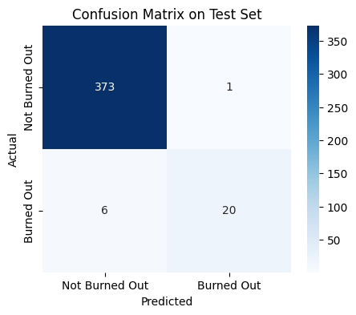

```python
import matplotlib.pyplot as plt
import seaborn as sns
from sklearn.metrics import classification_report, confusion_matrix


# Predictions
y_prob = final_model.predict(X_test_p)
y_pred = (y_prob > 0.5).astype(int).ravel()

# Compute macro F1-score
test_f1 = f1_score(y_test_int, y_pred, average="macro")
print(f"Test macro F1-score: {test_f1:.4f}\n")

# Classification report
print("Classification Report:")
print(classification_report(y_test_int, y_pred, zero_division=0))

# Confusion matrix
cm = confusion_matrix(y_test_int, y_pred)

plt.figure(figsize=(5,4))
sns.heatmap(cm, annot=True, fmt="d", cmap="Blues",xticklabels=["Not Burned Out", "Burned Out"],yticklabels=["Not Burned Out", "Burned Out"])
plt.xlabel("Predicted")
plt.ylabel("Actual")
plt.title("Confusion Matrix on Test Set")
plt.show()
```

## 9. Learning, Weaknesses, and Strengths

Strengths/Advantages

1. A pipeline that is leak-free and clean
2. Excellent performance
3. Unambiguous experiments
4. Effective neural network design

What Did I Discover? In basic datasets, hyperparameter adjustment has a greater impact on training stability than raw accuracy.

## 10.Recommendations

1)Assess using an actual HR dataset 2)For categorical characteristics, add embeddings or regularisation. 3)For explainability, use SHAP 4)Examine calibrated probabilities 5)Include the model in HR dashboards.

## 11.Conclusion

```python
import json
with open("M507_Methods of Prediction.ipynb", "r") as f:
    nb = json.load(f)
md_text = ""
for cell in nb["cells"]:
    if cell["cell_type"] == "markdown":
        md_text += "".join(cell["source"])
len(md_text)
```

```
12580
```

### Dataset link :

https://www.kaggle.com/datasets/ankam6010/synthetic-hr-burnout-dataset